# Лабораторная работа №9

Операционные системы

Куокконен Дарина Андреевна

Российский университет дружбы народов, Москва, Россия

04 апреля 2024

## Цель работы

Цель данной лабораторной работы - освоение основных возможностей командной оболочки Midnight Commander, приобретение навыков практической работы по просмотру каталогов и файлов

## Выполнение лабораторной работы

С помощью команды man mc читаю документацию про командную оболочку.

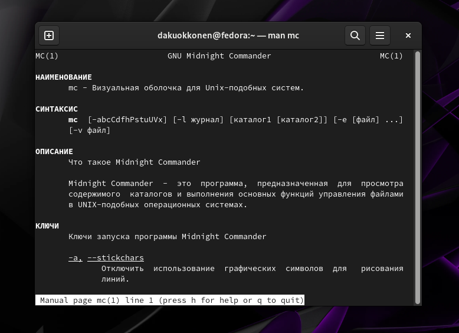

Чтение документации

## Выполнение лабораторной работы

Ввожу в терминале mc и получаю окно, в котором далее смогу работать.

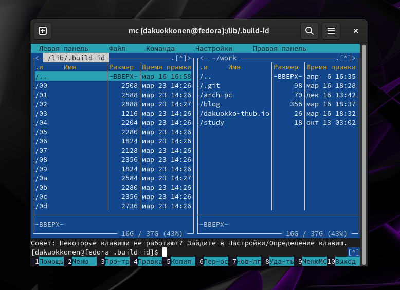

Окно mc

## Выполнение лабораторной работы

С помощью F5 могу создать копию файла в выбранном каталоге

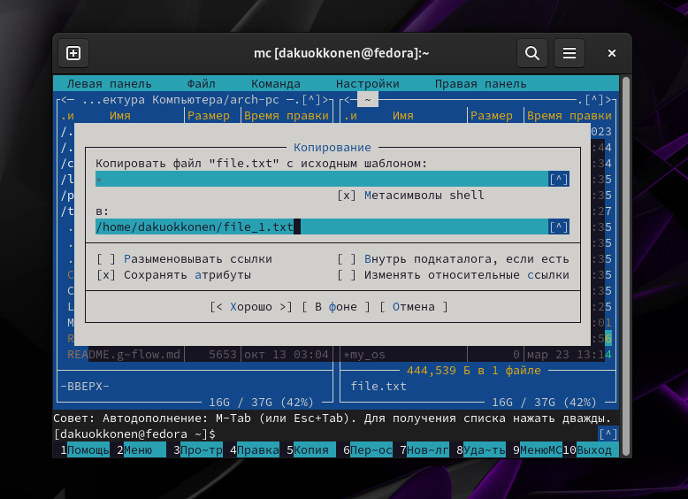

Копирование файла

## Выполнение лабораторной работы

С помощью управляющих клавиш так же можно получить информацию о правах доступа на файл и информацию о нем.

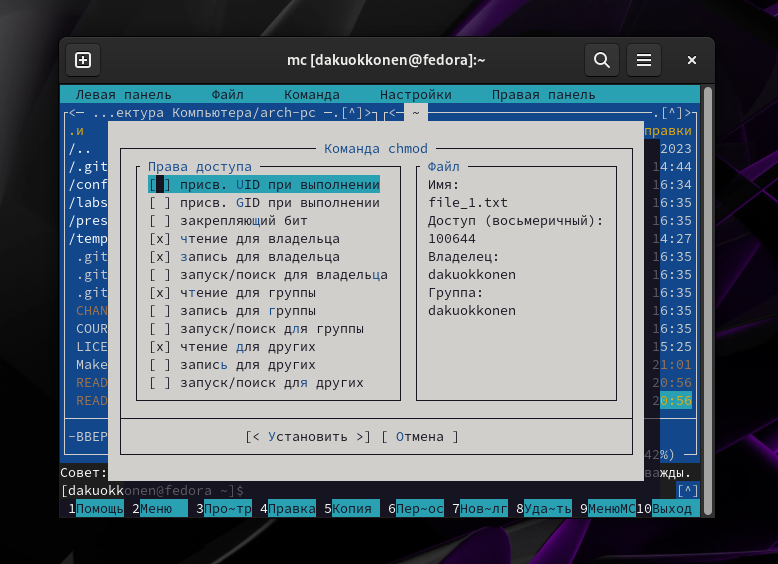

.

## Выполнение лабораторной работы

В меню правой панели вывожу информацию о файле.

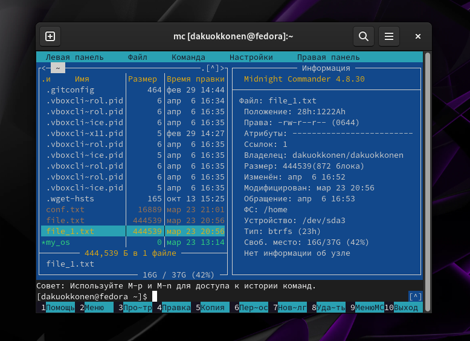

Вывод информации о файле

## Выполнение лабораторной работы

Смотрю содержимое текстового файла.

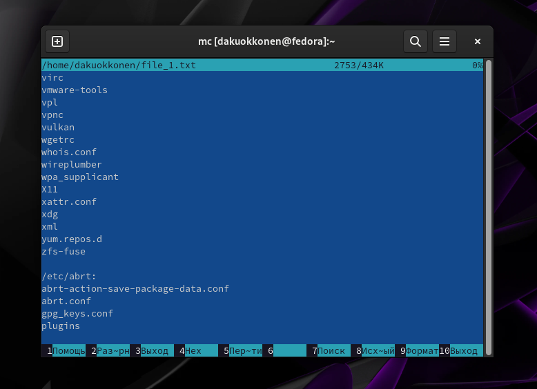

## Выполнение лабораторной работы

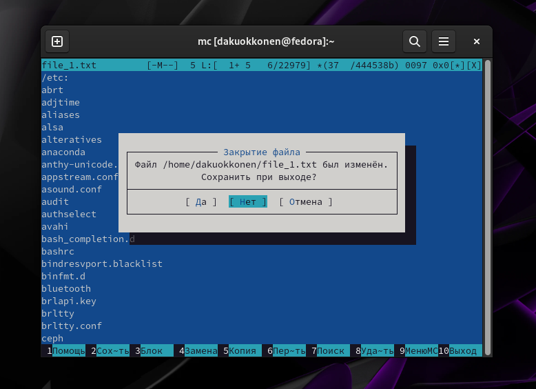

## Выполнение лабораторной работы

Создаю новый каталог.

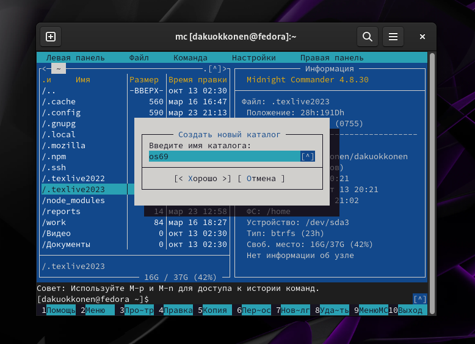

Создание нового каталога

## Выполнение лабораторной работы

Копирую файл в созданный каталог.

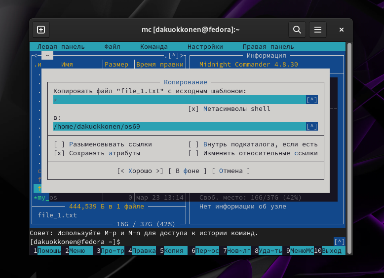

Копирование файла

## Выполнение лабораторной работы

С помощью средств ищу файлы с расширением “.с”

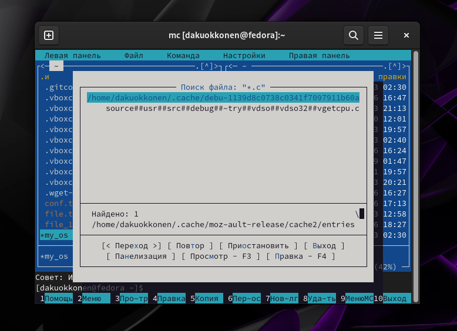

Поиск файла с фильтром

## Выполнение лабораторной работы

Можно перемещаться между директориями, например в домашнюю (рис. 11).

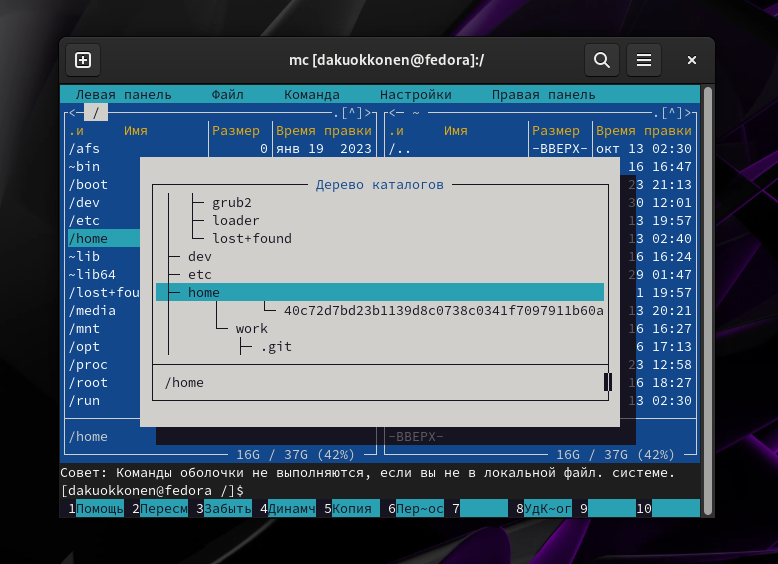

Перемещение в директорию

## Выполнение лабораторной работы

Из подменю “настройки” вызваю окна “настройки панели” (рис. 12)

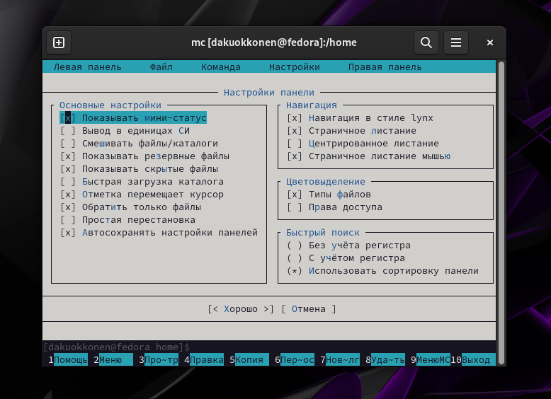

Настройки панели

## Выполнение лабораторной работы

Вызываю окно “настройки внешнего вида” (рис. 13)

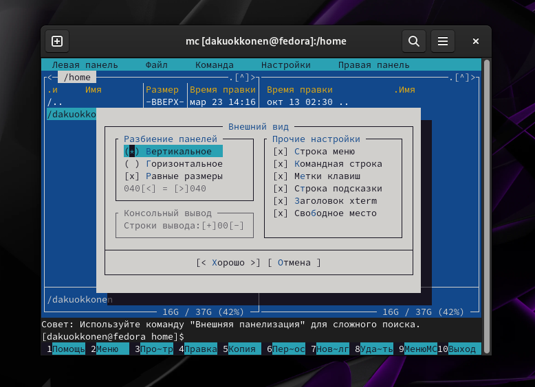

Настройки внешнего вида

## Выполнение лабораторной работы

Командой touch text.txt создала файл (рис. 14).

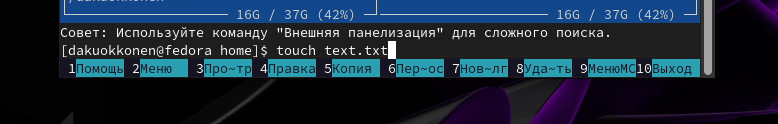

Создание файла

## Выполнение лабораторной работы

Клавишей F4 открываю файл для записи, добавляю в него текст (рис. 15).

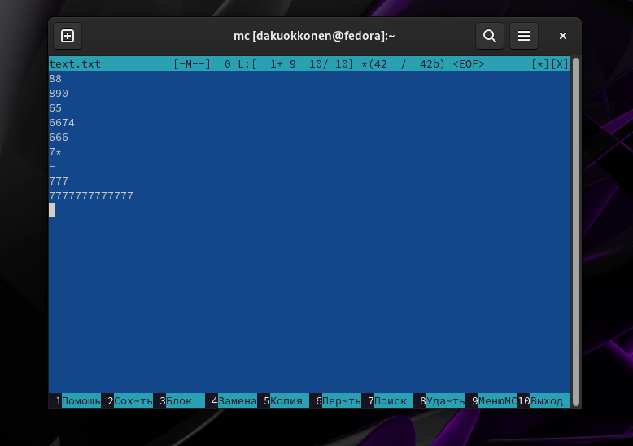

Открытие файла и запись в него

## Выполнение лабораторной работы

Выделяю текст кликами мыши, делаю блок через F3, перемещаю выделенный текст с помощью клавиши F6 (рис. 16).

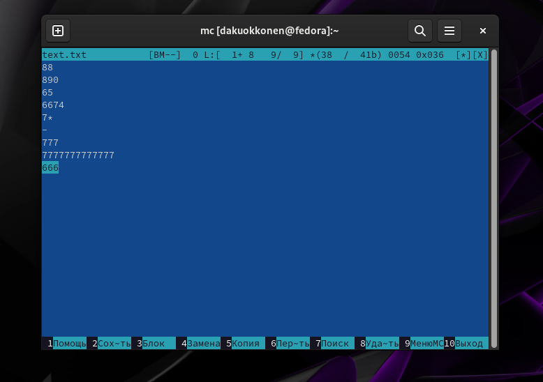

Выделение, перемещение текста

## Выполнение лабораторной работы

Удалиляю строку текста с помощью ctrl+y (рис. 17).

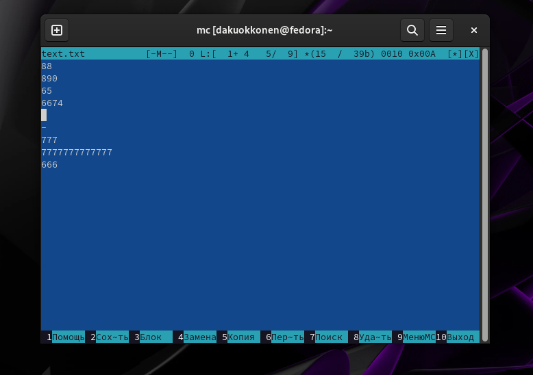

Удаление строки

## Выполнение лабораторной работы

Сохраняю изменения в файле с помощью горячей клавиши F2 (рис. 18).

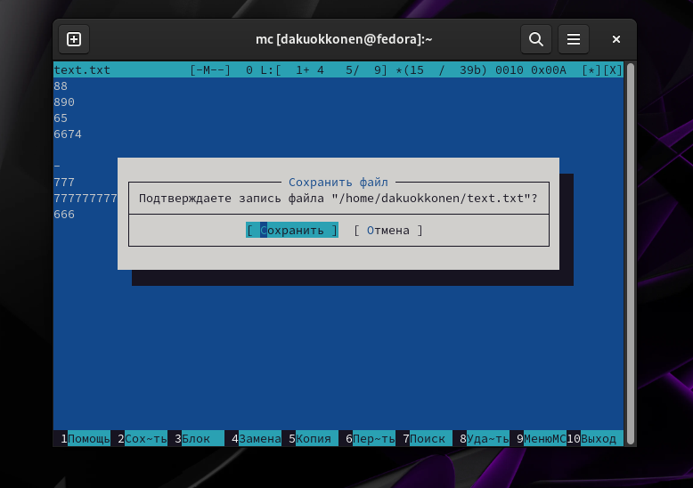

Сохранение изменений в файле

## Выполнение лабораторной работы

С помощью ctrl+u отменяю поседнее действие и возвращаю удаленную строку (рис. 19).

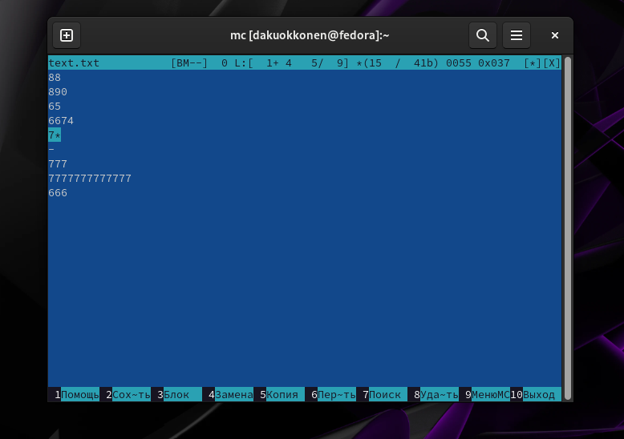

Отмена последнего действия

## Выполнение лабораторной работы

С помощью клавиш pgup, pgdn, у меня получилось попасть в начало и в конец файла соответственно, я добавил текст в начало и в конец файла (рис. 20).

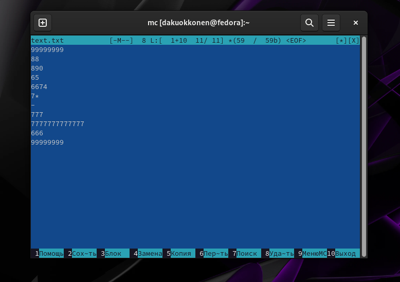

Добавление текста в начало и в конец файла

Закрываю файл, сохраняя изменения.

# Выводы

При выполнениии данной лабораторной работы я освоила основные возможности командной оболочки Midnight Commander, приобрела навыки практической работы по просмотру каталогов и файлов